# Dirty Presidents

Autogenerated data summary from dataReporter

2020-12-03 18:04:29

# Data report overview

The dataset examined has the following dimensions:

| Feature | Result |
| --- | --- |
| Number of observations | 46 |
| Number of variables | 11 |

### Checks performed

The following variable checks were performed, depending on the data type of each variable:

|  | character | factor | labelled | haven labelled | numeric | integer | logical | Date |
| --- | --- | --- | --- | --- | --- | --- | --- | --- |
| Identify miscoded missing values | × | × | × | × | × | × |  | × |
| Identify prefixed and suffixed whitespace | × | × | × | × |  |  |  |  |
| Identify levels with < 6 obs. | × | × | × | × |  |  |  |  |
| Identify case issues | × | × | × | × |  |  |  |  |
| Identify misclassified numeric or integer variables | × | × | × | × |  |  |  |  |
| Identify outliers |  |  |  |  | × | × |  | × |

Non-supported variable types were set to be handled in the following way:

- Name is treated as character

Please note that all numerical values in the following have been rounded to 2 decimals.

# Summary table

|  | Variable class | # unique values | Missing observations | Any problems? |
| --- | --- | --- | --- | --- |
| lastName | Name | 40 | 0.00 % | × |
| firstName | Name | 31 | 0.00 % | × |
| orderOfPresidency | factor | 46 | 0.00 % | × |
| birthday | Date | 45 | 0.00 % | × |
| stateOfBirth | character | 23 | 0.00 % | × |
| assassinationAttempt | numeric | 2 | 0.00 % |  |
| sex | factor | 1 | 0.00 % | × |
| ethnicity | factor | 2 | 0.00 % | × |
| presidencyYears | numeric | 11 | 4.35 % | × |
| ageAtInauguration | character | 23 | 0.00 % | × |
| favoriteNumber | complex | 11 | 0.00 % | × |

# Variable list

## lastName

| value | count | percentage |
| --- | --- | --- |
| Truman | 1 | 2.17% |
| Adams | 2 | 4.35% |
| Arathornson | 1 | 2.17% |
| Arthur | 1 | 2.17% |
| Buchanan | 1 | 2.17% |
| Bush | 2 | 4.35% |
| Carter | 1 | 2.17% |
| Cleveland | 2 | 4.35% |
| Clinton | 1 | 2.17% |
| Coolidge | 1 | 2.17% |
| Eisenhower | 1 | 2.17% |
| Fillmore | 1 | 2.17% |
| Ford | 1 | 2.17% |
| Garfield | 1 | 2.17% |
| Grant | 1 | 2.17% |
| Harding | 1 | 2.17% |
| Harrison | 2 | 4.35% |
| Hayes | 1 | 2.17% |
| Hoover | 1 | 2.17% |
| Jackson | 1 | 2.17% |
| Jefferson | 1 | 2.17% |
| Johnson | 2 | 4.35% |
| Kennedy | 1 | 2.17% |
| Lincoln | 1 | 2.17% |
| Madison | 1 | 2.17% |
| McKinley | 1 | 2.17% |
| Monroe | 1 | 2.17% |
| Nixon | 1 | 2.17% |
| Obama | 1 | 2.17% |
| Pierce | 1 | 2.17% |
| Polk | 1 | 2.17% |
| Reagan | 1 | 2.17% |
| Roosevelt | 2 | 4.35% |
| Taft | 1 | 2.17% |
| Taylor | 1 | 2.17% |
| Trump | 1 | 2.17% |
| Tyler | 1 | 2.17% |
| Van Buren | 1 | 2.17% |
| Washington | 1 | 2.17% |
| Wilson | 1 | 2.17% |
| NA | 0 | 0% |

- The following values appear with prefixed or suffixed white space: " Truman".
- Note that the following levels have at most five observations: " Truman", "Adams", "Arathornson", …, "Washington", "Wilson" (35 values omitted).

## firstName

| value | count | percentage |
| --- | --- | --- |
| . | 1 | 2.17% |
| Abraham | 1 | 2.17% |
| Andrew | 2 | 4.35% |
| Aragorn | 1 | 2.17% |
| Barack | 1 | 2.17% |
| Benjamin | 1 | 2.17% |
| Calvin | 1 | 2.17% |
| Chester | 1 | 2.17% |
| Dwight | 1 | 2.17% |
| Franklin | 2 | 4.35% |
| George | 3 | 6.52% |
| Gerald | 1 | 2.17% |
| Grover | 2 | 4.35% |
| Harry | 1 | 2.17% |
| Herbert | 1 | 2.17% |
| James | 5 | 10.87% |
| Jimmy | 1 | 2.17% |
| John | 4 | 8.7% |
| Lyndon | 1 | 2.17% |
| Martin | 1 | 2.17% |
| Millard | 1 | 2.17% |
| Richard | 1 | 2.17% |
| Ronald | 1 | 2.17% |
| Rutherford | 1 | 2.17% |
| Theodore | 1 | 2.17% |
| Thomas | 1 | 2.17% |
| Ulysses | 1 | 2.17% |
| Warren | 1 | 2.17% |
| William | 4 | 8.7% |
| Woodrow | 1 | 2.17% |
| Zachary | 1 | 2.17% |
| NA | 0 | 0% |

- The following suspected missing value codes enter as regular values: ".".
- Note that the following levels have at most five observations: ".", "Abraham", "Andrew", …, "Woodrow", "Zachary" (26 values omitted).

## orderOfPresidency

- The variable is a key (distinct values for each observation).

## birthday

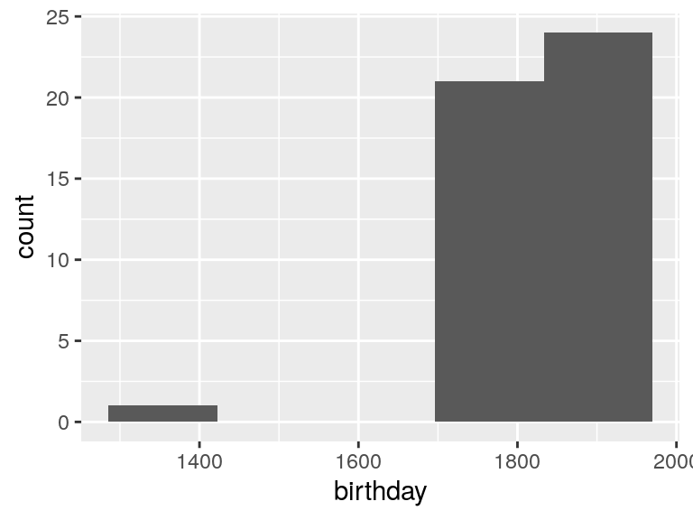

- Note that the following possible outlier values were detected: "1300-03-01".

## stateOfBirth

| value | count | percentage |
| --- | --- | --- |
| Arkansas | 1 | 2.17% |
| California | 1 | 2.17% |
| Connecticut | 1 | 2.17% |
| Georgia | 1 | 2.17% |
| Gondor | 1 | 2.17% |
| Hawaii | 1 | 2.17% |
| Illinois | 1 | 2.17% |
| Iowa | 1 | 2.17% |
| Kentucky | 1 | 2.17% |
| Massachusetts | 4 | 8.7% |
| Missouri | 1 | 2.17% |
| Nebraska | 1 | 2.17% |
| New Hampshire | 1 | 2.17% |
| New Jersey | 2 | 4.35% |
| New york | 1 | 2.17% |
| New York | 4 | 8.7% |
| North Carolina | 2 | 4.35% |
| Ohio | 8 | 17.39% |
| Pennsylvania | 1 | 2.17% |
| Tennessee | 1 | 2.17% |
| Texas | 2 | 4.35% |
| Vermont | 2 | 4.35% |
| Virginia | 7 | 15.22% |
| NA | 0 | 0% |

- Note that the following levels have at most five observations: "Arkansas", "California", "Connecticut", …, "Texas", "Vermont" (16 values omitted).
- Note that there might be case problems with the following levels: "New york", "New York".

## assassinationAttempt

- Note that this variable is treated as a factor variable below, as it only takes a few unique values.

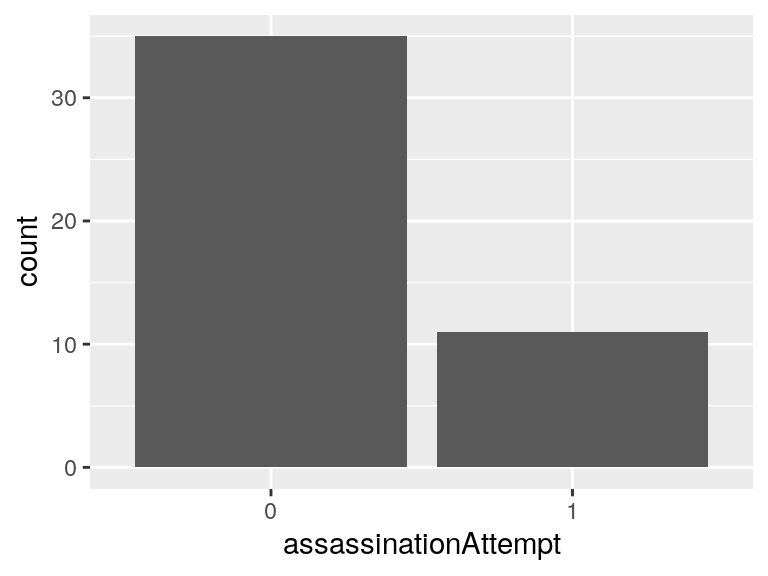

## sex

- The variable only takes one (non-missing) value: "Male". The variable contains 0 % missing observations.

## ethnicity

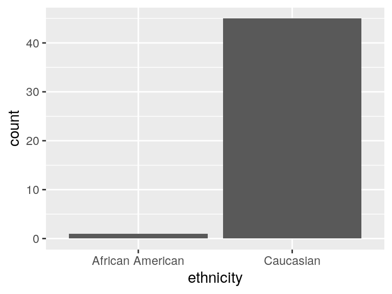

- Note that the following levels have at most five observations: "African American".

## presidencyYears

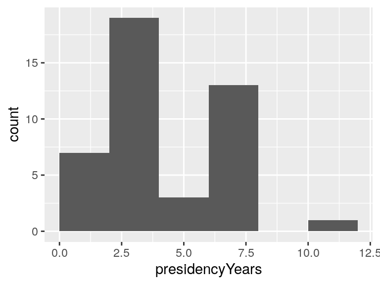

- The following suspected missing value codes enter as regular values: "Inf".
- Note that the following possible outlier values were detected: "0", "1", "2", "Inf".

## ageAtInauguration

| value | count | percentage |
| --- | --- | --- |
| 42 | 1 | 2.17% |
| 43 | 1 | 2.17% |
| 46 | 2 | 4.35% |
| 47 | 2 | 4.35% |
| 48 | 1 | 2.17% |
| 49 | 2 | 4.35% |
| 50 | 2 | 4.35% |
| 51 | 4 | 8.7% |
| 52 | 2 | 4.35% |
| 54 | 5 | 10.87% |
| 55 | 4 | 8.7% |
| 56 | 3 | 6.52% |
| 57 | 4 | 8.7% |
| 58 | 1 | 2.17% |
| 60 | 1 | 2.17% |
| 61 | 3 | 6.52% |
| 62 | 1 | 2.17% |
| 64 | 2 | 4.35% |
| 65 | 1 | 2.17% |
| 68 | 1 | 2.17% |
| 69 | 1 | 2.17% |
| 70 | 1 | 2.17% |
| 87 | 1 | 2.17% |
| NA | 0 | 0% |

- Note that the following levels have at most five observations: "42", "43", "46", …, "70", "87" (18 values omitted).
- Note: The variable consists exclusively of numbers and takes a lot of different values. Is it perhaps a misclassified numeric variable?

## favoriteNumber

- The variable has class complex which is not supported by dataReporter.

Report generation information:

- Created by: AHP (username: `root`).
- Report creation time: tor dec 03 2020 18:04:29
- Report was run from directory: `/home/ahp/bshome/Talks/whyR`
- dataReporter v1.0.0 [Pkg: 2020-12-02 from local]
- R version 4.0.2 (2020-06-22).
- Platform: x86_64-pc-linux-gnu (64-bit)(Ubuntu 18.04.5 LTS).
- Function call: `makeDataReport(data = presidentData, output = "html", mode = c("visualize", "check"), replace = TRUE, vol = "_example", visuals = setVisuals(character = "tableVisual"), maxProbVals = 5, reportTitle = "Dirty Presidents", treatXasY = list(Name = "character"))`